# Bayesian optimization

20/10/2025

## Metamodelling

We now have some tools for the design of experiments phase, let’s go over to the next.

[figure not shown]

## Panorama of alternatives

## Two illustrative data sets

Let us take two examples of design of experiments results, one deterministic and one noisy.

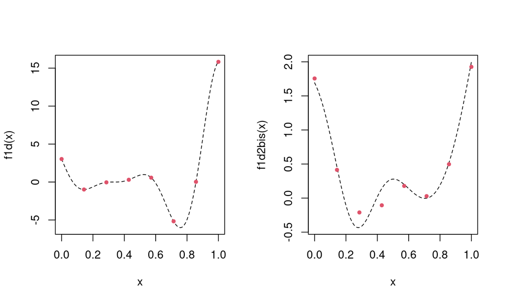

## Linear regression in a nutshell (1/2)

- bases functions: \(f_1, \dots, f_p\)
- design of experiments \(\mathbf{X} = (\mathbf{x_1}, \dots, \mathbf{x_n})^\top\)
- observations \(\mathbf{y} = (y_1, \dots, y_n)^\top\)
- \(\mathbf{F} = \begin{bmatrix} f_1(\mathbf{x}_1) & \dots & f_p(\mathbf{x}_1) \\ &\vdots & \\ f_1(\mathbf{x}_n) & \dots & f_p(\mathbf{x}_n) \end{bmatrix}\)

Model: \(Y(\mathbf{x}) = \mathbf{f}(\mathbf{x}) \boldsymbol{\beta} + \epsilon\) with \(\epsilon \sim \mathcal{N}(0, \sigma^2)\)

The BLUP (best linear unbiased estimate) of \(\boldsymbol{\beta}\) is given by \(\hat{\boldsymbol{\beta}} = (\mathbf{F}^\top\mathbf{F})^{-1}\mathbf{F} \mathbf{y}\)

\(cov(\hat{\beta}_i, \hat{\beta}_j) = \sigma^2 (\mathbf{F}^\top \mathbf{F})^{-1}\)

*Exercise*:

- what is the variance of the prediction \(\hat{y}(\mathbf{x}) = \mathbf{f}(\mathbf{x}) \hat{\boldsymbol{\beta}}\)?

## Linear regression in a nutshell (2/2)

\(Var(\hat{y}(\mathbf{x}))= \sigma^2 \mathbf{f}(\mathbf{x}) (\mathbf{F}^\top \mathbf{F})^{-1} \mathbf{f}(\mathbf{x})^\top\)

*Result on the two examples:*

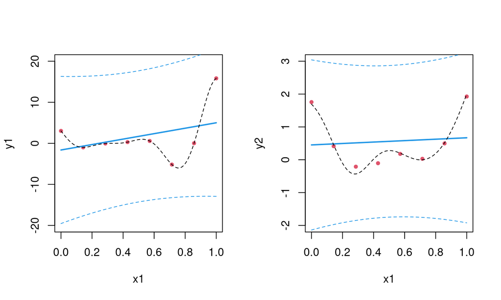

## Random forests

Random forests are ensemble of decision trees (see e.g., [3])

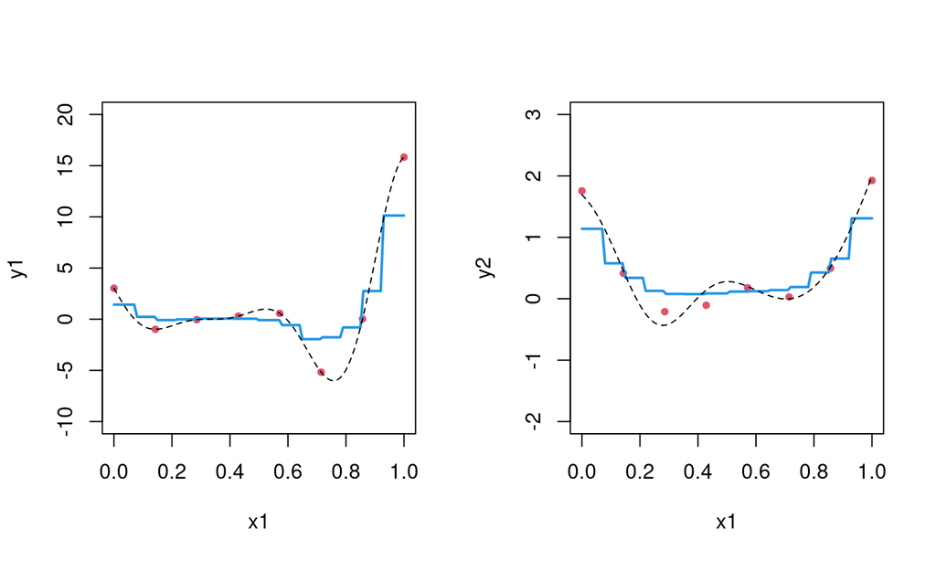

[3] Breiman L (2001). “Random Forests”. Machine Learning. 45 (1): 5–32.

## Neural nets

Neural networks are versatile emulators.

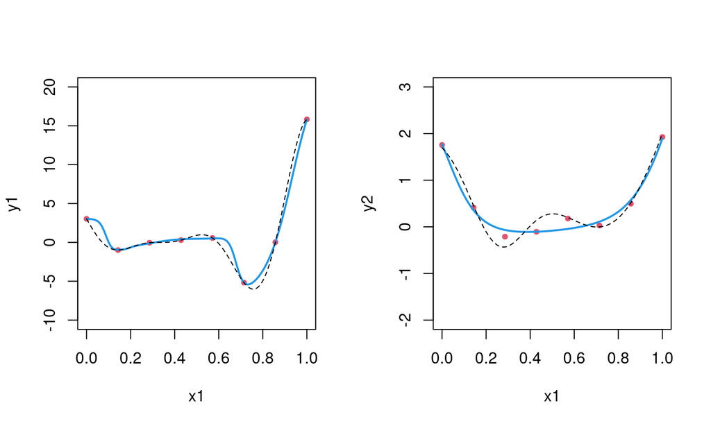

## Splines

Splines are piece-wise polynomials passing through control points. Smoothing splines work on noisy data.

Below: cubic splines (third order polynomials)

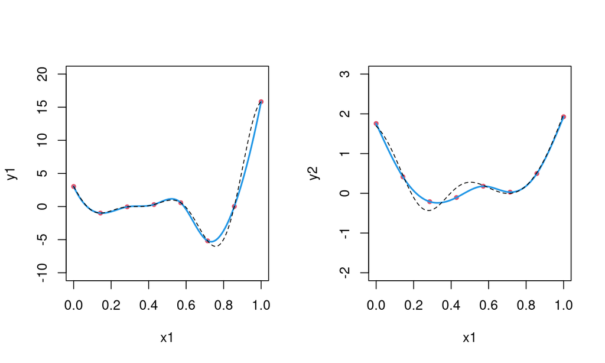

## MARS [5]

Multivariate Adaptive Regression Splines use hinge functions and cutpoints to define predictors.

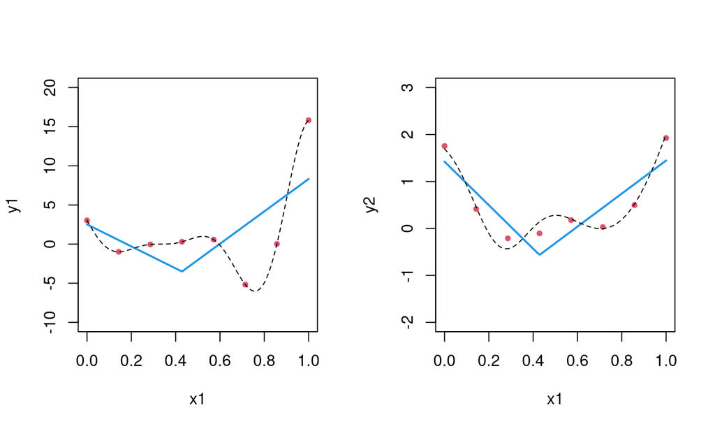

[5] Hastie, T.; Tibshirani, R.; Friedman, J. The elements of statistical learning. Springer, 2009, 2

## Summary

So far none of the previous method is completely satisfying:

- some would require much more data to become accurate;
- it is not clear how some would be adapted for optimization, in particular to ensure convergence when sequentially refining;
- stability with the increase of dimension varies;
- deterministic and noisy setups are mostly treated the same;
- there is only poor (if any) predictive variance information available.

As we will see, Gaussian processes provide a good solution to all of these issues.

## Normal and multivariate normal distribution reminder

## Covariance

Recall that the covariance measures the joint variability of two random variables.

It is defined as: \(Cov(X, Y) = \mathbb{E}((X - \bar{X}) (Y - \bar{Y}))\).

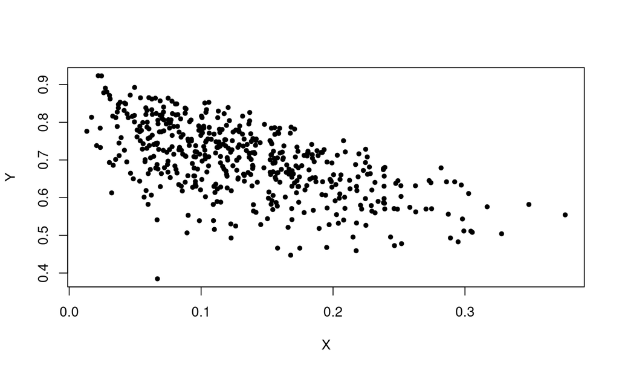

The empirical estimator is: \(\frac{1}{N - 1} \sum \limits_{i = 1}^N \left(X_i - \bar{X}\right)\left(Y_i - \bar{Y} \right)\)

## Gaussian distribution

The normal distribution \(\mathcal{N}(\mu,\sigma^2)\) is ubiquitous is many fields, with \(\mu\) the mean and \(\sigma^2\) the variance.

Its probability density function is \(\phi_{\mu, \sigma^2}(x) = \frac{1}{\sigma\sqrt{2\pi}} \exp\left( - \frac{(x - \mu)^2}{2\sigma^2} \right)\)

and cumulative distribution function \(\Phi_{\mu, \sigma^2}(x) = \frac{1}{2} \left[1 + \mathrm{erf}\left( \frac{x-\mu}{\sigma \sqrt{2}} \right) \right]\).

A **fundamental** property is that the sum of two Gaussian variables is Gaussian (linked to CLT).

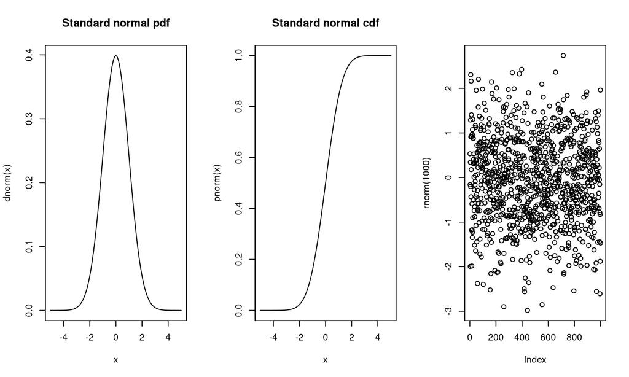

## Multivariate Gaussian distribution

This is the vectorial generalization of the Gaussian distribution.

Its pdf is \(f_{X}(x_1, \dots, x_k) = \frac{1}{\sqrt{(2 \pi)^k |\boldsymbol{\Sigma}|}} \exp \left(-\frac{1}{2} (\mathbf{x} - \boldsymbol{\mu})^\top \Sigma^{-1} (\mathbf{x} - \boldsymbol{\mu}) \right)\) (\(| \boldsymbol{\Sigma}| > 0\))

where \(\boldsymbol{\mu}\) is the mean and \(\boldsymbol{\Sigma}\) the covariance matrix (symmetric positive definite).

*Example* with \(\boldsymbol{\mu} = [0,1]\) and \(\boldsymbol{\Sigma} = \begin{bmatrix} 1 & 0.75\\ 0.75 & 2 \end{bmatrix}\)

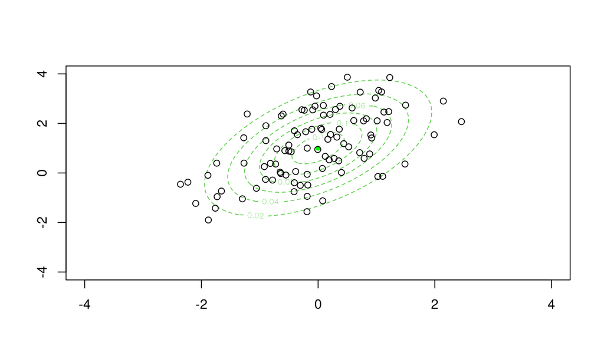

## Key properties of Gaussian vectors

**Prop. 1**: a random vector \(Y \in \mathbf{R}^n\) is said Gaussian iif \(\forall \mathbf{a} \in \mathbf{R}^n\), \(\mathbf{a}^\top Y\) is Gaussian

**Prop. 2**: \(\epsilon \sim \mathcal{N}(0, Id) \Rightarrow \Omega \epsilon \sim \mathcal{N}(0, Id)\) with \(\Omega\) s.t. \(\Omega \Omega^\top = Id\)

**Prop. 3**: \(X_1, \dots, X_n\) is independent \(\Leftrightarrow cov(X_i, X_j) = 0 ~\forall i,j \Leftrightarrow \Sigma = Id\)

Gaussian vectors are solely determined by their (arbitrary) mean and (psd) covariance.

## Toward covariance functions

Now suppose that we have performed a design of experiments and that we have data: \((x_1, y_1), \dots, (x_n, y_n)\).

**Crucial** hypothesis: we assume that \(Y_n = (y_1, \dots, y_n)\) has a multivariate normal distribution.

Ok, but with what mean and covariance?

- for the mean, unless we have some additional knowledge it should maybe be constant;
- for the covariance, it is reasonable to assume that if \(x_i\) and \(x_j\) are close (resp. far away), then \(y_i\) and \(y_j\) will be highly (resp. lowly) correlated.

Let’s see where this gets us.

## Covariance structure

Consider a covariance function defined by Euclidean distance:

\[Cov(Y(x), Y(x')) = \Sigma(x, x') = \exp(-||x - x'||^2)\]

- the covariance is decaying exponentially fast as the distance grows in the design space.
- \(\Sigma(x, x) = 1\) and \(0 < \Sigma(x, x) < 1\) if \(x \neq x'\).

Based on the design, this gives a covariance matrix \(\Sigma_n\) s.t. \(\Sigma_{n}^{ij} = \Sigma(x_i, x_j)\).

To be valid, a covariance function must lead to a positive definite \(\Sigma_n\), for all possible distinct values of \(x_1, \dots, x_n\).

(More on this later)

## Data generating mecanism

Before going for regression, consider draws from our MVN prior, i.e., generate data based on this covariance setup.

To this end:

- take some \(x_1, \dots ,x_n\) values
- define \(\Sigma_n^{ij} = \Sigma(x_i, x_j), 1 \leq i,j \leq n\)
- draw realizations from \(Y \sim \mathcal{N}(0_n, \Sigma_n)\)
- plot the result

## 1d-example in R

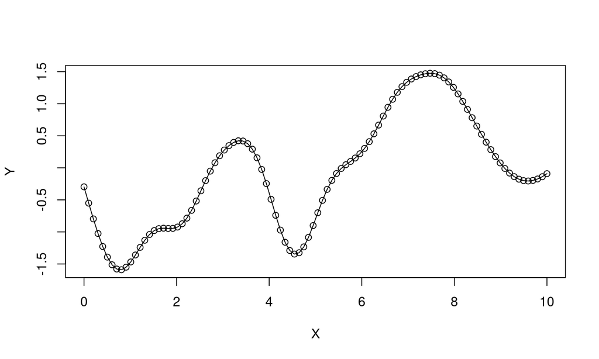

```r
n <- 100
X <- matrix(seq(0, 10, length=n), ncol=1)
D <- as.matrix(dist(X))
eps <- sqrt(.Machine$double.eps) ## defining a small number
Sigma <- exp(-D^2 + diag(eps, n))  ## for numerical stability
library(mvtnorm, quietly=TRUE)
Y <- rmvnorm(1, sigma=Sigma)
plot(X, Y, type = "l"); points(X, Y)
```

## Multiple draws

Un-surprinsingly, the point-wise range is [-2,2] with 95% probability.

Realizations are smooth (due to the covariance function).

There are several bumps because long distances are almost uncorrelated:

```r
c(exp(-1^2), exp(-4^2))
```

```
## [1] 3.678794e-01 1.125352e-07
```

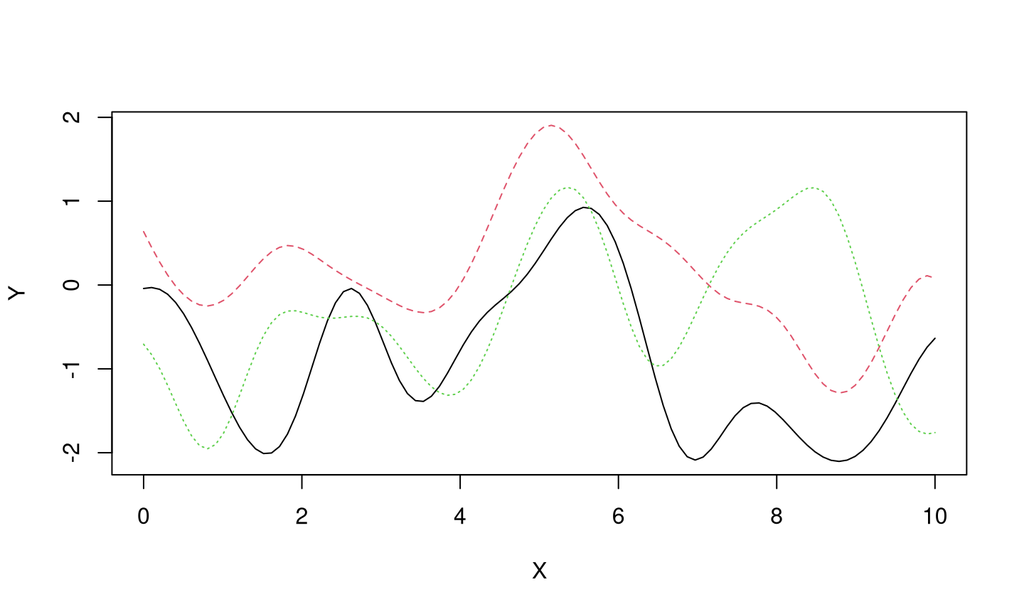

## Gaussian process (GP)

So far we are able to generate random functions. In fact, we are already looking at GPs

**Gaussian process**: a random process \(Y\) indexed by \(D\) is said Gaussian iif \(\forall n \in \mathbf{N}, x_i \in D, 1 \leq i \leq n\), the realization vector (or observations) \((Y(x_1), \dots, Y(x_n))\) is a Gaussian vector, that is, it has a multivariate normal distribution.

We denote it by: \(Y(\cdot) \sim \mathcal{GP}(m(\cdot), k(\cdot, \cdot))\)

But we would obviously like to use the \(y\) values.

That is, we would be interesting in random realizations that explain those values.

In other words, we are interested in the conditional distribution of \(Y(x) | (X_n, Y_n)\).

## Gaussian process regression

## MVN partition & conditioning

From [Wikipedia](https://en.wikipedia.org/wiki/Multivariate_normal_distribution#Conditional_distributions), if an \(n\)-dimensional random multivariate normal (MVN) vector \(Y\) is partitioned as

\[ Y = \left( \begin{array}{c} Y_1 \\ Y_2 \end{array} \right) \quad \mbox{ with sizes } \quad \left( \begin{array}{c} q \times 1 \\ (n-q) \times 1 \end{array} \right), \]

and accordingly \(\mu\) and \(\Sigma\) are partitioned as,

\[ \begin{aligned} \mu &= \left( \begin{array}{c} \mu_1 \\ \mu_2 \end{array} \right) & \mbox{ with sizes } & \left( \begin{array}{c} q \times 1 \\ (n-q) \times 1 \end{array} \right), \quad \mbox{and} \\ \Sigma &= \left(\begin{array}{cc} \Sigma_{11} & \Sigma_{12} \\ \Sigma_{21} & \Sigma_{22} \end{array} \right) & \mbox{ with sizes } & \left(\begin{array}{cc} q \times q & q \times (n-q) \\ (n-q)\times q & (n - q)\times (n-q) \end{array} \right), \end{aligned} \]

… then, \(Y_1 \mid Y_2 \sim \mathcal{N}_q (\bar{\mu}, \bar{\Sigma})\), where

\[ \begin{aligned} \bar{\mu} &= \mu_1 + \Sigma_{12} \Sigma_{22}^{-1}(Y_2 - \mu_2) \\ \mbox{and } \quad \bar{\Sigma} &= \Sigma_{11} - \Sigma_{12} \Sigma_{22}^{-1} \Sigma_{21}. \end{aligned} \]

## Details on the derivation

For a full proof, see e.g., [here](http://www.math.chalmers.se/~rootzen/highdimensional/SSP4SE-appA.pdf).

\(y = (y_1, y_2)\), \(n-q = r\)

\(f_Y(y) = ((2\pi)^{n}det(\Sigma))^{1/2} \exp{(-1/2(y - \mu)^\top \Sigma^{-1} (y - \mu))} = f_{Y_1Y_2}(y_1, y_2)\)

\(f_{Y_2}(y_2) = ((2\pi)^{n}det(\Sigma_{22}))^{1/2} \exp{(-1/2(y_2 - \mu_2)^\top \Sigma_{22}^{-1} (y_2 - \mu_2))}\)

Conditional density of \(Y_1\) given \(Y_2 = y_2\) is \(f_{Y_1|Y_2}(y_1 | y_2) = \frac{f_{Y_1Y_2}(y_1, y_2)}{f_{Y_2(y_2)}}\)

The result follows by using the “Matrix inversions lemma”:

Let \(B = \left(\begin{array}{cc} B_{11} & B_{12} \\ B_{21} & B_{22} \end{array} \right)\), \(A = B^{-1} = \left(\begin{array}{cc} A_{11} & A_{12} \\ A_{21} & A_{22} \end{array} \right)\). Then

\[A = \left(\begin{array}{cc} (B_{11} - B_{12} B_{22}^{-1}B_{21})^{-1} & -(B_{11} - B_{12} B_{22}^{-1} B_{21})^{-1}B_{12}B_{22}^{-1} \\ -(B_{22} - B_{21}B_{11}^{-1}B_{12})^{-1}B_{21}B_{11}^{-1} & (B_{22} -B_{21} B_{11}^{-1}B_{12})^{-1} \end{array} \right)\] and identifying the terms.

## GP prediction or “kriging”

GP prediction, \(Y(\mathcal{X}) \mid D_n\) at new locations \(\mathcal{X}\), is just a special case (mean zero) of those conditional MVN equations:

\[ Y(\mathcal{X}) \mid D_n \sim \mathcal{N}_{n'}(\mu(\mathcal{X}), \Sigma(\mathcal{X})) \]

with

\[ \begin{aligned} \mbox{mean } \quad \mu(\mathcal{X}) &= \Sigma(\mathcal{X}, X_n) \Sigma_n^{-1} Y_n \\ \mbox{and variance } \quad \Sigma(\mathcal{X}) &= \Sigma(\mathcal{X},\mathcal{X}) - \Sigma(\mathcal{X}, X_n) \Sigma_n^{-1} \Sigma(\mathcal{X}, X_n)^\top. \end{aligned} \]

- where \(\Sigma(\mathcal{X}, X_n)\) is an \(n' \times n\) matrix.

These are the so-called “kriging” equations in spatial statistics.

- They describe the best (minimizing MSPE) linear unbiased predictor (BLUP).

## Noise modeling

Assuming that the noise is Gaussian, a simple model is: \[Y(\mathbf{X_n}) = f(\mathbf{X_n}) + \boldsymbol{\epsilon}_n\] with \(f(\mathbf{X_n}) \sim \mathcal{N}(\mu(\mathbf{X}_n), \Sigma(\mathbf{X_n}))\) and \(\epsilon \sim \mathcal{N}(0, \sigma_\epsilon^2)\)

From the independence of \(\epsilon\) and properties of the Gaussian distribution, we will see that the difference with the deterministic case is minimal:

- \(Cov(x_i, x_j) = \Sigma(x_i, x_j)\) if \(i \neq j\)
- \(Cov(x_i, x_i) = \Sigma(x_i, x_i) + \sigma^2_\epsilon\)

In fact is even more convenient to reparameterize \(\epsilon \sim \mathcal{N}(0, \sigma_\epsilon^2)\) to \(\epsilon \sim \mathcal{N}(0, \nu \tau^2)\).

## Hyperparameters

If the covariance structure is (hyper-) parameterized,

\[ Y_n \sim \mathcal{N}_n(0, \nu (C_n + \tau^2\mathbb{I}_n)) \quad \mbox{where} \quad C_{\theta}(\cdot, \cdot) = \exp\left\{ - \sum_{k=1}^d \frac{(x_k - x'_k)^2}{\theta_k} \right\}, \]

then use the MVN to define a (log) “likelihood” for the unknowns \((\nu, \theta, \tau^2)\). \[ \ell = \log L = -\frac{n}{2} \log 2\pi - \frac{N}{2} \log \nu - \frac{1}{2} \log |K_n| - \frac{1}{2\nu} Y_n^\top K_n^{-1} Y_n, \] where \(K_n = C_n + \tau^2 \mathbb{I}_n\). To maximize \(\ell\) with respect to \(\nu\) just differentiate and solve. \[ \begin{aligned} 0 \stackrel{\mathrm{set}}{=} \ell'(\nu) \equiv \frac{\partial \ell}{\partial \nu} &= - \frac{n}{2 \nu} + \frac{1}{2 \nu^2} Y_n^\top K_n^{-1} Y_n \\ \hat{\nu}_n &= \frac{Y_n^\top K_n^{-1} Y_n}{n} \end{aligned} \]

## Concentrated log likelihood

Now, plugging \(\hat{\nu}\) into \(\ell\) gives the so-called **concentrated log likelihood**,

\[ \begin{aligned} \ell(\tau^2, \theta) &= -\frac{n}{2} \log 2\pi - \frac{n}{2} \log \hat{\nu} - \frac{1}{2\hat{\nu}} Y_n^\top K_n^{-1} Y_n \\ &= c - \frac{n}{2} \log Y_n K_n^{-1} Y_n - \frac{1}{2} \log |K_n|. \end{aligned} \]

Using the chain rule and that

\[ \frac{\partial K_n^{-1}}{\partial \phi} = - K_n^{-1} \frac{\partial K_n}{\partial \phi} K_n^{-1} \quad \mbox{ and } \quad \frac{\partial \log | K_n | }{\partial \phi} = \mathrm{tr} \left \{ K_n^{-1} \frac{\partial K_n}{\partial \phi} \right\} \]

yields closed-form expressions for the partial derivatives wrt \((\theta_1, \dots, \theta_k)\) and \(\tau^2\).

- Unfortunately these cannot be set to zero and solved analytically.
- so numerical optimization is required …

Time to try it!

## Result

Example of Gaussian process regression:

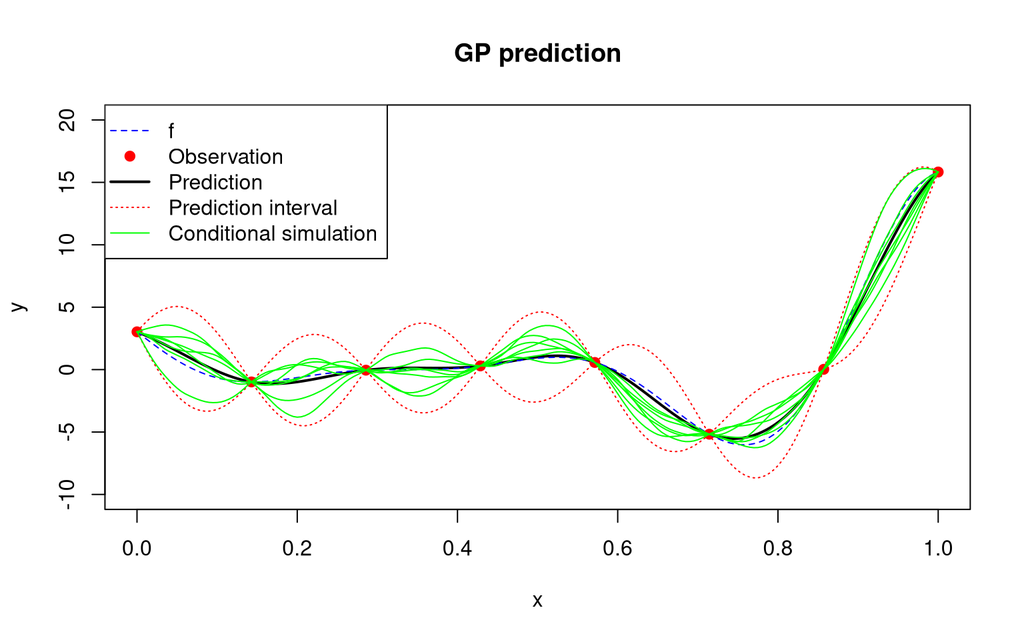

## Back to the initial problems

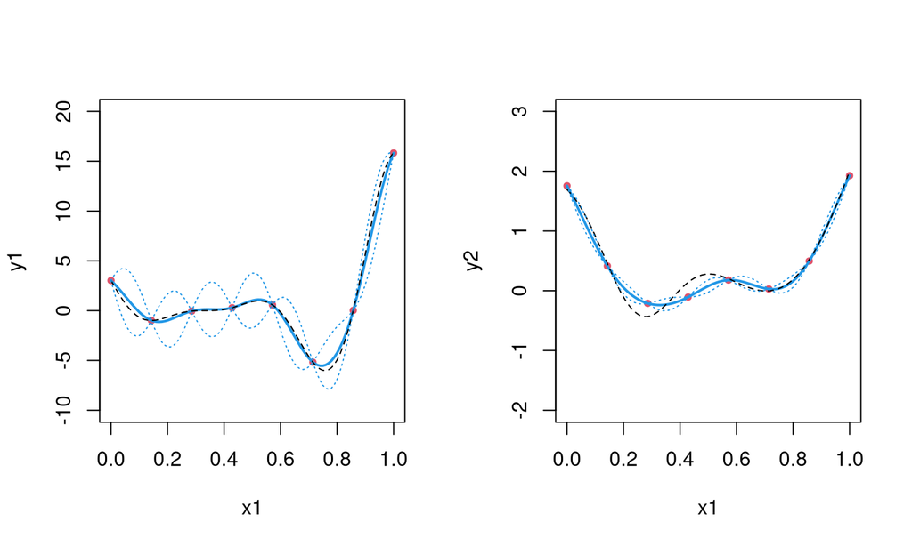

## Summary

We now have a new metamodeling tool, that can be parameterized by a mean and a covariance function.

GPs not only provide a prediction everywhere, they also give meaningful uncertainty quantification information via the predictive variance.

How to best exploit these features?

## Ressources:

Garnett, R. (2021). Bayesian Optimization Book. [available online](https://bayesoptbook.com/)

Gramacy, R. B. (2020). Surrogates: Gaussian Process Modeling, Design, and Optimization for the Applied Sciences, CRC Press. [available online](https://bobby.gramacy.com/surrogates/)

Roustant, O. (2024). Metamodeling with Gaussian processes. [available online](https://hal.science/hal-04509167v1/file/Metamodeling_textbook.pdf)

Williams, C. K., & Rasmussen, C. E. (2006). Gaussian processes for machine learning. Cambridge, MA: MIT press. available online

Website with many lectures on GPs: [Gaussian process summer schools](http://gpss.cc/)